# Project _ CreditCard Users Churn Prediction (DA)

## Logistic Regression

Oversampling by means of SMOTE (Synthetic Minority Over Sampling Technique)

```
Before UpSampling, counts of label 'Yes': 1464
Before UpSampling, counts of label 'No': 7648

After UpSampling, counts of label 'Yes': 7648
After UpSampling, counts of label 'No': 7648


After UpSampling, the shape of train_X: (15296, 22)
After UpSampling, the shape of train_y: (15296,)


Accuracy on training set :  80.9811237928007
Accuracy on test set :  78.38104639684107
Recall on training set :  78.82513661202186
Recall on test set :  73.61963190184049
Precision on training set :  44.780752813348855
Precision on test set :  40.54054054054054

True-Positive:  120
True-Negative:  674
False-Positive:  176
False-Negative:  43
```

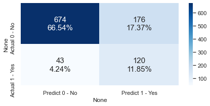

```python
from imblearn.over_sampling import SMOTE
print("Before UpSampling, counts of label 'Yes': {}".format(sum(y_train==1)))
print("Before UpSampling, counts of label 'No': {} \n".format(sum(y_train==0)))
sm = SMOTE(sampling_strategy = 1, k_neighbors = 3, random_state=1)
X_train_over, y_train_over = sm.fit_resample(X_train, y_train)
print("After UpSampling, counts of label 'Yes': {}".format(sum(y_train_over==1)))
print("After UpSampling, counts of label 'No': {} \n".format(sum(y_train_over==0)))
print()
print('After UpSampling, the shape of train_X: {}'.format(X_train_over.shape))
print('After UpSampling, the shape of train_y: {} \n'.format(y_train_over.shape))
print()
LR=LogisticRegression(random_state=1).fit(X_train_over,y_train_over)
LRScore=mscore(LR)
cm(LR, y_train_over)
```

*Accuracy became worse but I suppose that is what is expected to represent less bias data (without a validation set)*

## Bagging Classifiers

```
~~~~~~~~~~ DecisionTree ~~~~~~~~~~
Accuracy on training set :  100.0
Accuracy on test set :  87.06811451135242
Recall on training set :  100.0
Recall on test set :  65.6441717791411
Precision on training set :  100.0
Precision on test set :  58.791208791208796

True-Positive:  107
True-Negative:  775
False-Positive:  75
False-Negative:  56
```

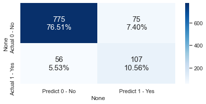

```
~~~~~~~~~~ RandomForest ~~~~~~~~~~
Accuracy on training set :  100.0
Accuracy on test set :  91.70779861796645
Recall on training set :  100.0
Recall on test set :  71.16564417177914
Precision on training set :  100.0
Precision on test set :  75.81699346405229

True-Positive:  116
True-Negative:  813
False-Positive:  37
False-Negative:  47
```

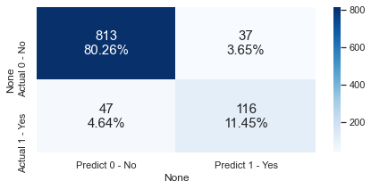

```
~~~~~~~~~~ Bagging ~~~~~~~~~~
Accuracy on training set :  99.63784021071115
Accuracy on test set :  91.609081934847
Recall on training set :  99.1120218579235
Recall on test set :  72.39263803680981
Precision on training set :  98.64038069340585
Precision on test set :  74.68354430379746

True-Positive:  118
True-Negative:  810
False-Positive:  40
False-Negative:  45
```

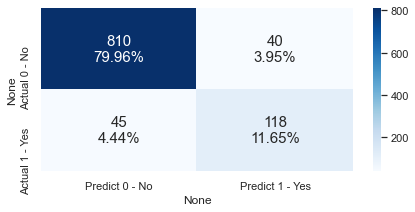

```
Wall time: 5.08 s
```

```python
%%time

DT = DecisionTreeClassifier(random_state=1)
RF = RandomForestClassifier(random_state=1)
B  = BaggingClassifier(random_state=1)

DT.fit(X_train_over,y_train_over)
RF.fit(X_train_over,y_train_over)
B.fit(X_train_over,y_train_over)

lines=('~'*10)

print(lines,'DecisionTree',lines)
mscore(DT)
cm(DT,y_test)
plt.show()
print(lines,'RandomForest',lines)
mscore(RF)
cm(RF,y_test)
plt.show()
print(lines,'Bagging', lines)
mscore(B)
cm(B,y_test)
plt.show()
```

- Logistic regression performed very poorly.
- Random forest and decision tree models were overfitting Train but performed well on Test.
- The same is true of Bagging

## Boosting Classifiers

```
~~~~~~~~~~ GradientBoosting ~~~~~~~~~~
Accuracy on training set :  92.8884986830553
Accuracy on test set :  92.30009871668312
Recall on training set :  84.6311475409836
Recall on test set :  77.30061349693251
Precision on training set :  74.54873646209387
Precision on test set :  75.44910179640718

True-Positive:  126
True-Negative:  809
False-Positive:  41
False-Negative:  37
```

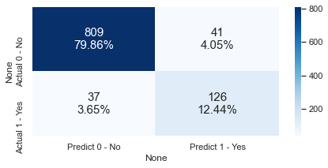

```
~~~~~~~~~~ AdaBoost ~~~~~~~~~~
Accuracy on training set :  90.18876207199298
Accuracy on test set :  88.94373149062191
Recall on training set :  79.57650273224044
Recall on test set :  75.4601226993865
Precision on training set :  66.19318181818183
Precision on test set :  63.07692307692307

True-Positive:  123
True-Negative:  778
False-Positive:  72
False-Negative:  40
```

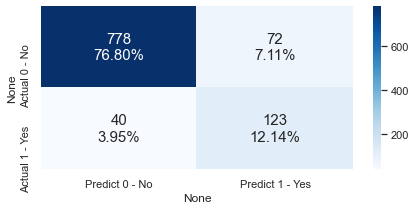

```
~~~~~~~~~~ XGBoost ~~~~~~~~~~
Accuracy on training set :  99.4073748902546
Accuracy on test set :  92.39881539980257
Recall on training set :  99.1120218579235
Recall on test set :  73.61963190184049
Precision on training set :  97.2520107238606
Precision on test set :  77.92207792207793

True-Positive:  120
True-Negative:  816
False-Positive:  34
False-Negative:  43
```

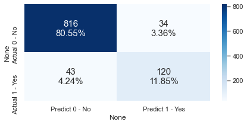

```
Wall time: 8.47 s
```

```python
%%time
GB=GradientBoostingClassifier(random_state=1)
ADAB=AdaBoostClassifier(random_state=1)
XGB=XGBClassifier(random_state=1,eval_metric='logloss')

GB.fit(X_train_over,y_train_over)
ADAB.fit(X_train_over,y_train_over)
XGB.fit(X_train_over,y_train_over)

print(lines,'GradientBoosting',lines)
mscore(GB)
cm(GB,y_train_over)
plt.show()
print(lines,'AdaBoost',lines)
mscore(ADAB)
cm(ADAB,y_train_over)
plt.show()
print(lines,'XGBoost', lines)
mscore(XGB)
cm(XGB,y_train_over)
plt.show()
```

- GradientBoosting & XGBoost did the best with a bit of overfitting on Train but also did well on Tes with a high precision.

```python
comparemodels = [DT ,RF ,B ,GB ,ADAB ,XGB]
acc_test, acc_train, precision_test, precision_train, recall_test, recall_train=compareM(comparemodels)

comparison_frame = pd.DataFrame(
    {
        "Model": [
            "DecisionTree",
            "RandomForest",
            "Boosting",
            "GradientBoost",
            "ADABoost",
            "XGBoost",]
        ,
        "Train_Accuracy": acc_train,
        "Test_Accuracy": acc_test,
        "Train_Recall": recall_train,
        "Test_Recall": recall_test,
        "Train_Precision": precision_train,
        "Test_Precision": precision_test,
    }
)


comparison_frame.sort_values(by="Test_Precision", ascending=False)
```

|  | Model | Train_Accuracy | Test_Accuracy | Train_Recall | Test_Recall | Train_Precision | Test_Precision |
| --- | --- | --- | --- | --- | --- | --- | --- |
| 5 | XGBoost | 99.407375 | 92.398815 | 99.112022 | 73.619632 | 97.252011 | 77.922078 |
| 1 | RandomForest | 100.000000 | 91.707799 | 100.000000 | 71.165644 | 100.000000 | 75.816993 |
| 3 | GradientBoost | 92.888499 | 92.300099 | 84.631148 | 77.300613 | 74.548736 | 75.449102 |
| 2 | Boosting | 99.637840 | 91.609082 | 99.112022 | 72.392638 | 98.640381 | 74.683544 |
| 4 | ADABoost | 90.188762 | 88.943731 | 79.576503 | 75.460123 | 66.193182 | 63.076923 |
| 0 | DecisionTree | 100.000000 | 87.068115 | 100.000000 | 65.644172 | 100.000000 | 58.791209 |

```python
comparison_frame.sort_values(by="Test_Accuracy", ascending=False)
```

|  | Model | Train_Accuracy | Test_Accuracy | Train_Recall | Test_Recall | Train_Precision | Test_Precision |
| --- | --- | --- | --- | --- | --- | --- | --- |
| 5 | XGBoost | 99.407375 | 92.398815 | 99.112022 | 73.619632 | 97.252011 | 77.922078 |
| 3 | GradientBoost | 92.888499 | 92.300099 | 84.631148 | 77.300613 | 74.548736 | 75.449102 |
| 1 | RandomForest | 100.000000 | 91.707799 | 100.000000 | 71.165644 | 100.000000 | 75.816993 |
| 2 | Boosting | 99.637840 | 91.609082 | 99.112022 | 72.392638 | 98.640381 | 74.683544 |
| 4 | ADABoost | 90.188762 | 88.943731 | 79.576503 | 75.460123 | 66.193182 | 63.076923 |
| 0 | DecisionTree | 100.000000 | 87.068115 | 100.000000 | 65.644172 | 100.000000 | 58.791209 |

**Insight into Choosing the best model**

Resulting XGBoost, RandomForest , GradientBoost as our top three to build the pipe build.

```
RandomForest Classifier: 95.13053279964595
GradientBoosting Classifier: 93.79146214957468
XGB Classifier: 95.49536833229425
```

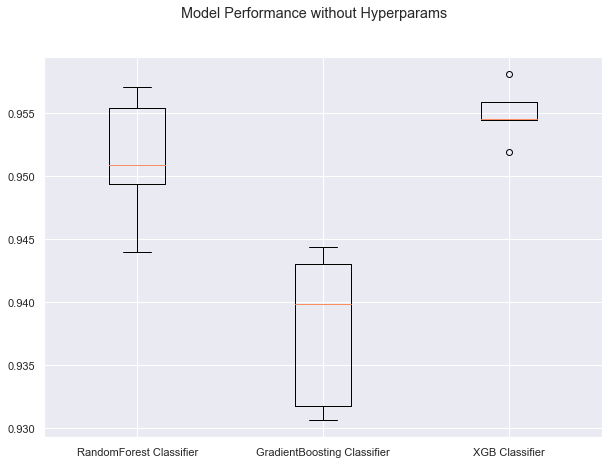

```
Wall time: 30.8 s
```

```python
%%time
models = []

models.append(
    (
        "RandomForest Classifier",
        Pipeline(
            steps=[
                ("scaler", StandardScaler()),
                ("random_forest", RandomForestClassifier(random_state=1)),
            ]
        ),
    )
)
models.append(
    (
        "GradientBoosting Classifier",
        Pipeline(
            steps=[
                ("scaler", StandardScaler()),
                ("gradient_boosting", GradientBoostingClassifier(random_state=1)),
            ]
        ),
    )
)
models.append(
    (
        "XGB Classifier",
        Pipeline(
            steps=[
                ("scaler", StandardScaler()),
                ("xgboost", XGBClassifier(random_state=1,eval_metric='logloss')),
            ]
        ),
    )
)


# Cookie-Cutter loop
results = []
names = []
for name, model in models:
    kfold = StratifiedKFold(n_splits=5, shuffle=True, random_state=1)
    cv_result = cross_val_score(estimator=model, X=X_train_over, y=y_train_over, scoring="precision", cv=kfold)
    results.append(cv_result)
    names.append(name)
    print("{}: {}".format(name, cv_result.mean() * 100))
print()

# Cookie Cutter - boxplot for CV scores of all models defined above
fig = plt.figure(figsize=(10, 7))

fig.suptitle("Model Performance without Hyperparams")
ax = fig.add_subplot(111)

plt.boxplot(results)
ax.set_xticklabels(names)

plt.show()
```

## RandomizedSearchCV

```python
%%time

# XGBoost with Hyper Param
#Creating pipeline
XGB_pipe = make_pipeline(StandardScaler(),XGBClassifier(random_state=1,eval_metric='logloss', n_estimators = 50))
param_grid={'xgbclassifier__n_estimators':np.arange(50,300,50),'xgbclassifier__scale_pos_weight':[0,1,2,5,10],
            'xgbclassifier__learning_rate':[0.01,0.1,0.2,0.05],           'xgbclassifier__gamma':[0,1,3,5],
            'xgbclassifier__subsample':[0.7,0.8,0.9,1],               'xgbclassifier__max_depth':np.arange(1,10,1),
            'xgbclassifier__reg_lambda':[0,1,2,5,10]
           }

# Type of scoring used to compare parameter combinations
scorer = metrics.make_scorer(metrics.precision_score)
randomized_cv = RandomizedSearchCV(estimator=XGB_pipe, param_distributions=param_grid, n_iter=25, scoring=scorer, cv=3, random_state=1)

#Fitting parameters in RandomizedSearchCV
XGB_pipe =randomized_cv.fit(X_train_over,y_train_over)

print("Best parameters are {} with CV score={}:" .format(randomized_cv.best_params_,randomized_cv.best_score_))
```

```
Best parameters are {'xgbclassifier__subsample': 0.7, 'xgbclassifier__scale_pos_weight': 1, 'xgbclassifier__reg_lambda': 2, 'xgbclassifier__n_estimators': 250, 'xgbclassifier__max_depth': 8, 'xgbclassifier__learning_rate': 0.1, 'xgbclassifier__gamma': 0} with CV score=0.9557368200733034:
Wall time: 1min 46s
```

```python
%%time
# GradientBoostingClassifier
#Creating pipeline
GB_pipe = (GradientBoostingClassifier(init=AdaBoostClassifier(random_state=1),random_state=1))
param_grid= {
    "n_estimators": [100,150,200,250],
    "subsample":[0.8,0.9,1],
    "max_features":[0.7,0.8,0.9,1]
}


# Type of scoring used to compare parameter combinations
scorer = metrics.make_scorer(metrics.precision_score)
randomized_cv = RandomizedSearchCV(estimator=GB_pipe, param_distributions=param_grid, n_iter=25, scoring=scorer, cv=3, random_state=1)

#Fitting parameters in RandomizedSearchCV
GB_pipe =randomized_cv.fit(X_train_over,y_train_over)
print("Best parameters are {} with CV score={}:" .format(randomized_cv.best_params_,randomized_cv.best_score_))
```

```
Best parameters are {'subsample': 0.8, 'n_estimators': 250, 'max_features': 0.8} with CV score=0.945856145138738:
Wall time: 4min 23s
```

```python
%%time

# RandomForestClassifier
#Creating pipeline
RF_pipe = RandomForestClassifier(class_weight={0:0.18,1:0.82},random_state=1,oob_score=True,bootstrap=True)
param_grid= {
    'max_depth': list(np.arange(5,30,5)) + [None],
                'max_features': ['sqrt','log2',None],
                'min_samples_leaf': np.arange(1,15,5),
                'min_samples_split': np.arange(2, 20, 5),
                'n_estimators': np.arange(10,110,10)}
# Type of scoring used to compare parameter combinations
scorer = metrics.make_scorer(metrics.precision_score)
randomized_cv = RandomizedSearchCV(estimator=RF_pipe, param_distributions=param_grid, n_iter=25, scoring=scorer, cv=3, random_state=1)

#Fitting parameters in RandomizedSearchCV
RF_pipe = randomized_cv.fit(X_train_over,y_train_over)
print("Best parameters are {} with CV score={}:" .format(randomized_cv.best_params_,randomized_cv.best_score_))
```

```
Best parameters are {'n_estimators': 90, 'min_samples_split': 2, 'min_samples_leaf': 1, 'max_features': 'sqrt', 'max_depth': None} with CV score=0.9513966141989699:
Wall time: 1min 44s
```

```python
%%time

comparison_frame_pipe_randCV = [XGB_pipe , GB_pipe , RF_pipe]
acc_test, acc_train, precision_test, precision_train, recall_test, recall_train=compareM(comparison_frame_pipe_randCV)

comparison_frame2 = pd.DataFrame(
    {
        "Model": ["XGBoost_RandomSearchCV", "GradientBoost_RandomSearchCV", "RandomForest_RandomSearchCV" ]
        ,
        "Train_Accuracy": acc_train,
        "Test_Accuracy": acc_test,
        "Train_Recall": recall_train,
        "Test_Recall": recall_test,
        "Train_Precision": precision_train,
        "Test_Precision": precision_test,
    }
)

comparison_frame2.sort_values(by="Test_Precision", ascending=False)
```

```
Wall time: 851 ms
```

|  | Model | Train_Accuracy | Test_Accuracy | Train_Recall | Test_Recall | Train_Precision | Test_Precision |
| --- | --- | --- | --- | --- | --- | --- | --- |
| 0 | XGBoost_RandomSearchCV | 99.524133 | 80.263158 | 100.000000 | 74.846626 | 99.524133 | 80.263158 |
| 1 | GradientBoost_RandomSearchCV | 80.189873 | 75.460123 | 86.543716 | 75.460123 | 80.189873 | 75.460123 |
| 2 | RandomForest_RandomSearchCV | 100.000000 | 75.000000 | 100.000000 | 68.098160 | 100.000000 | 75.000000 |

### Grid Search

```python
%%time

# RandomForestClassifier
rf_pipe = RandomForestClassifier(class_weight={0:0.18,1:0.82},random_state=1,oob_score=True,bootstrap=True)
#Creating pipeline
param_grid= {
    'max_depth': list(np.arange(5,30,5)) + [None],
                'max_features': ['sqrt','log2',None],
                'min_samples_leaf': np.arange(1,15,5),
                'min_samples_split': np.arange(2, 20, 5),
                'n_estimators': np.arange(10,110,10)}
# Type of scoring used to compare parameter combinations
scorer = metrics.make_scorer(metrics.precision_score)
grid_cv = GridSearchCV(rf_pipe , param_grid, scoring='recall',cv=3,n_jobs=-1)
#Fitting parameters in RandomizedSearchCV
rf_pipe = grid_cv.fit(X_train_over,y_train_over)
print("Best parameters are {} with CV score={}:" .format(grid_cv.best_params_,grid_cv.best_score_))
```

```python
%%time

# RandomForestClassifier
gb_pipe = GradientBoostingClassifier(init=AdaBoostClassifier(random_state=1),random_state=1)
#Creating pipeline
param_grid= {
    "n_estimators": [100,150,200,250],
    "subsample":[0.8,0.9,1],
    "max_features":[0.7,0.8,0.9,1]
}
# Type of scoring used to compare parameter combinations
scorer = metrics.make_scorer(metrics.precision_score)
grid_cv = GridSearchCV(gb_pipe, param_grid, scoring=acc_scorer,cv=3)
#Fitting parameters in RandomizedSearchCV
gb_pipe = grid_cv.fit(X_train_over,y_train_over)
print("Best parameters are {} with CV score={}:" .format(grid_cv.best_params_,grid_cv.best_score_))
```

```python
%%time
xgb_pipe = XGBClassifier(random_state=1)
# Grid of parameters to choose from
param_grid = {
    "n_estimators": np.arange(10,100,20),
    "scale_pos_weight":[0,1,2,5],
    "subsample":[0.5,0.7,0.9,1],
    "learning_rate":[0.01,0.1,0.2,0.05],
    "gamma":[0,1,3],
    "colsample_bytree":[0.5,0.7,0.9,1],
    "colsample_bylevel":[0.5,0.7,0.9,1]
}
# Type of scoring used to compare parameter combinations
acc_scorer = metrics.make_scorer(metrics.recall_score)
# Run the grid search
grid_cv = GridSearchCV(xgb_pipe, parameters,scoring=acc_scorer,cv=3)
grid_cv = grid_cv.fit(X_train, y_train)
# Set the clf to the best combination of parameters
xgb_pipe = grid_cv.fit(X_train_over,y_train_over)
print("Best parameters are {} with CV score={}:" .format(grid_cv.best_params_,grid_cv.best_score_))
```

```python
%%time

comparison_frame_pipe_gridCV = [xgb_pipe , gb_pipe , rf_pipe]
acc_test, acc_train, precision_test, precision_train, recall_test, recall_train=compareM(comparison_frame_pipe_randCV)

comparison_frame3 = pd.DataFrame(
    {
        "Model": ["XGBoost_GridSearchCV", "GradientBoost_GridSearchCV", "RandomForest_GridSearchCV" ]
        ,
        "Train_Accuracy": acc_train,
        "Test_Accuracy": acc_test,
        "Train_Recall": recall_train,
        "Test_Recall": recall_test,
        "Train_Precision": precision_train,
        "Test_Precision": precision_test,
    }
)

comparison_frame3.sort_values(by="Test_Precision", ascending=False)
```

-

## Comparing all models

```python
comparison_frame= comparison_frame.append(comparison_frame2)
```

```python
comparison_frame
# # comparison_frame = comparison_frame.append(comparison_frame3)
```

|  | Model | Train_Accuracy | Test_Accuracy | Train_Recall | Test_Recall | Train_Precision | Test_Precision |
| --- | --- | --- | --- | --- | --- | --- | --- |
| 0 | DecisionTree | 100.000000 | 87.068115 | 100.000000 | 65.644172 | 100.000000 | 58.791209 |
| 1 | RandomForest | 100.000000 | 91.707799 | 100.000000 | 71.165644 | 100.000000 | 75.816993 |
| 2 | Boosting | 99.637840 | 91.609082 | 99.112022 | 72.392638 | 98.640381 | 74.683544 |
| 3 | GradientBoost | 92.888499 | 92.300099 | 84.631148 | 77.300613 | 74.548736 | 75.449102 |
| 4 | ADABoost | 90.188762 | 88.943731 | 79.576503 | 75.460123 | 66.193182 | 63.076923 |
| 5 | XGBoost | 99.407375 | 92.398815 | 99.112022 | 73.619632 | 97.252011 | 77.922078 |
| 0 | XGBoost_RandomSearchCV | 99.524133 | 80.263158 | 100.000000 | 74.846626 | 99.524133 | 80.263158 |
| 1 | GradientBoost_RandomSearchCV | 80.189873 | 75.460123 | 86.543716 | 75.460123 | 80.189873 | 75.460123 |
| 2 | RandomForest_RandomSearchCV | 100.000000 | 75.000000 | 100.000000 | 68.098160 | 100.000000 | 75.000000 |

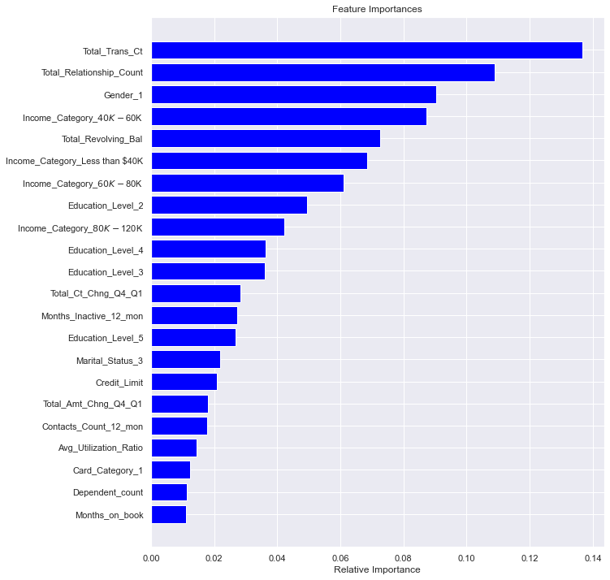

|  | Importance |
| --- | --- |
| Total_Trans_Ct | 0.136749 |
| Total_Relationship_Count | 0.108869 |
| Gender_1 | 0.090408 |
| Income_Category_$40K - $60K | 0.087250 |
| Total_Revolving_Bal | 0.072485 |
| Income_Category_Less than $40K | 0.068614 |
| Income_Category_$60K - $80K | 0.061060 |
| Education_Level_2 | 0.049526 |
| Income_Category_$80K - $120K | 0.042156 |
| Education_Level_4 | 0.036291 |
| Education_Level_3 | 0.036060 |
| Total_Ct_Chng_Q4_Q1 | 0.028270 |
| Months_Inactive_12_mon | 0.027198 |
| Education_Level_5 | 0.026834 |
| Marital_Status_3 | 0.021825 |
| Credit_Limit | 0.020934 |
| Total_Amt_Chng_Q4_Q1 | 0.018085 |
| Contacts_Count_12_mon | 0.017919 |
| Avg_Utilization_Ratio | 0.014542 |
| Card_Category_1 | 0.012272 |
| Dependent_count | 0.011435 |
| Months_on_book | 0.011219 |

```python
importantFeatures(XGB, True)
```

- Out of all the models XGBoost without RandomSearchCV had the best performance.
- While Test Test_Precision increased, accuracy dropped substatially, by about 12 points with a cv of 3 and 25 iterations.
- Perhaps raising this would yield better values but due to harward limitations, this could not be tested.
- Grid Search never completed for any of the models after waiting 4 hours so it will be excluded from this comparison.
- This leads us to conclude that Random Search is a much faster method for Hypertuning
- As for the features most important features, they are as follows, however no single one was extraordinarly impactful:
  - Total_Trans_Ct, Total_Relationship_Count, Gender_1,Income*Category* 40𝐾− 60K, Total_Revolving_Bal

# Business Recommendations

In the effots to curb Customers’ leaving credit cards services leading to future financial opportunity loss, The bank should focus on customer behavior features Total_Trans_Ct, Total_Relationship_Count, and Total_Revolving_Bal.

Men (Gender_1) that have an Income Category of 40𝐾− 60K(Income*Category* 40𝐾− 60K) are the customer classification/profile to focus on as these are the highest ones of impact.

Using these features, I would recommend to possibly offer some kind of promotion to them or reach out to them for more personalized service. Perhaps collecting additional data for further analysis would be of benefit.